# Final Project 2026

## IMPORTANT:

read carefully the instruction for the final project in the pdf file

**Project2026_INFO.pdf**

This Notebook contains only the description of the dataset and some preliminary data visualizations.

## 1) Bike sharing Data.

**Source.** https://www.kaggle.com/code/juniorbueno/rental-bikes/notebook

**Data.** The data contains the number of casual/registered users in bike sharing systems and various additional covariates (related to the weather) as well information on days/month/year.

instant: record index

dteday : date

season : season (1:winter, 2:spring, 3:summer, 4:fall)

yr : year (0: 2011, 1:2012)

mnth : month ( 1 to 12)

hr : hour (0 to 23)

holiday : weather day is holiday or not

weekday : day of the week

workingday : if day is neither weekend nor holiday is 1, otherwise is 0.

weathersit :

1: Clear, Few clouds, Partly cloudy, Partly cloudy

2: Mist + Cloudy, Mist + Broken clouds, Mist + Few clouds, Mist

3: Light Snow, Light Rain + Thunderstorm + Scattered clouds, Light Rain + Scattered clouds

4: Heavy Rain + Ice Pallets + Thunderstorm + Mist, Snow + Fog

temp : Normalized temperature in Celsius. The values are derived via (t-tmin)/ (tmax-tmin), tmin=-8, t_max=+39 (only in hourly scale)

atemp: Normalized feeling temperature in Celsius. The values are derived via (t-tmin)/(tmax-tmin), tmin=-16, t_max=+50 (only in hourly scale)

hum: Normalized humidity. The values are divided to 100 (max)

windspeed: Normalized wind speed. The values are divided to 67 (max)

casual: count of casual users

registered: count of registered users

cnt: count of total rental bikes including both casual and registered

**Task.** Fit a regression model to predict the total number of rented bikes (or, alternatively, the number of casual or registered users). Since the counts are relatively large, you may consider using the logarithm of the counts together with a Gaussian model. Discuss the impact of the different variables, paying particular attention to the presence of several categorical covariates. Perform model selection and include a prediction exercise.

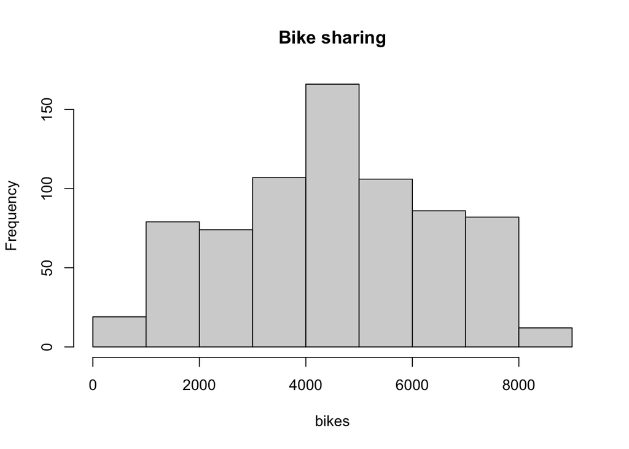

```r
rm(list=ls())
#bike
#https://www.kaggle.com/code/juniorbueno/rental-bikes/input?select=day.csv
data = read.csv("data/bike.csv")
hist(data$cnt,main="Bike sharing",xlab="bikes")
```

```r
data = data.frame(data[,3:16])
dim(data)
```

```
## [1] 731  14
```

```r
head(data)
```

|  | season | yr | mnth | holiday | weekday | workingday | weathersit | temp | atemp | hum | windspeed | casual | registered | cnt |
| --- | --- | --- | --- | --- | --- | --- | --- | --- | --- | --- | --- | --- | --- | --- |
| 1 | 1 | 0 | 1 | 0 | 6 | 0 | 2 | 0.344167 | 0.363625 | 0.805833 | 0.1604460 | 331 | 654 | 985 |
| 2 | 1 | 0 | 1 | 0 | 0 | 0 | 2 | 0.363478 | 0.353739 | 0.696087 | 0.2485390 | 131 | 670 | 801 |
| 3 | 1 | 0 | 1 | 0 | 1 | 1 | 1 | 0.196364 | 0.189405 | 0.437273 | 0.2483090 | 120 | 1229 | 1349 |
| 4 | 1 | 0 | 1 | 0 | 2 | 1 | 1 | 0.200000 | 0.212122 | 0.590435 | 0.1602960 | 108 | 1454 | 1562 |
| 5 | 1 | 0 | 1 | 0 | 3 | 1 | 1 | 0.226957 | 0.229270 | 0.436957 | 0.1869000 | 82 | 1518 | 1600 |
| 6 | 1 | 0 | 1 | 0 | 4 | 1 | 1 | 0.204348 | 0.233209 | 0.518261 | 0.0895652 | 88 | 1518 | 1606 |

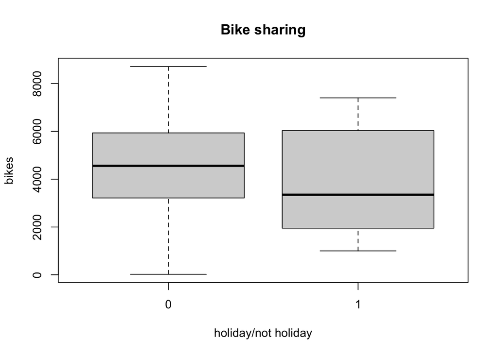

```r
boxplot(data$cnt~data$holiday,xlab="holiday/not holiday",ylab="bikes",main="Bike sharing")
```

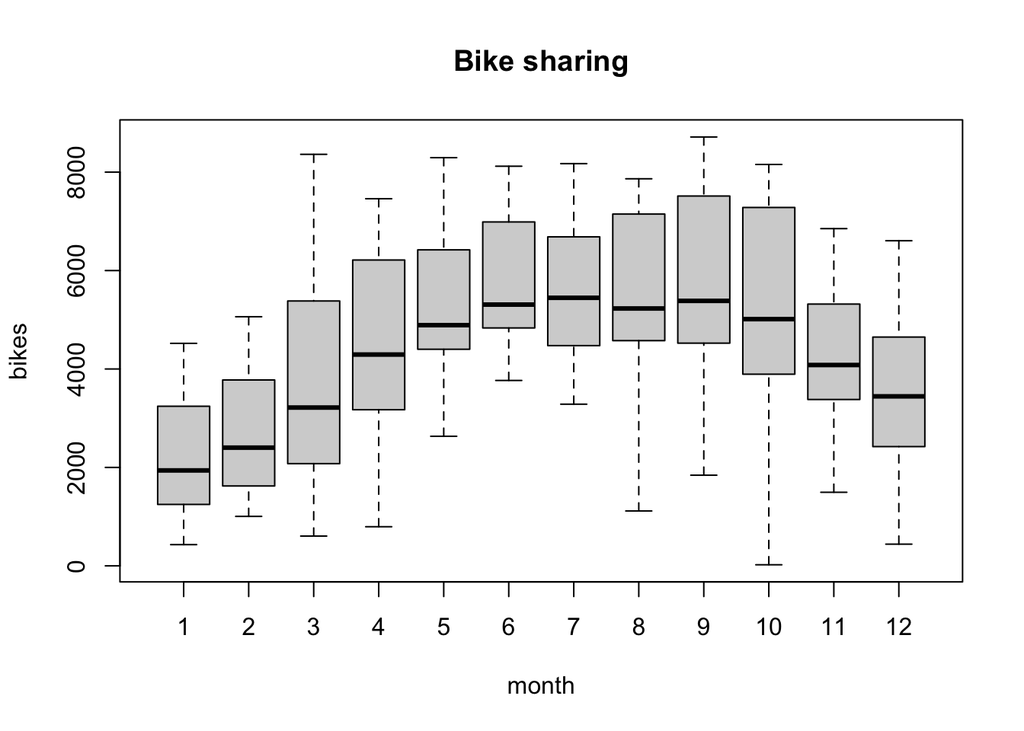

```r
boxplot(data$cnt~data$mnth,ylab="bikes",xlab="month",main="Bike sharing")
```

```r
data_s=data.frame(data[,8:12])
data_s =data.frame(apply(data_s,2,as.numeric))
data_s$casual=(data_s$casual-mean(data_s$casual))/sd(data_s$casual)
head(data_s)
```

|  | temp | atemp | hum | windspeed | casual |
| --- | --- | --- | --- | --- | --- |
| 1 | 0.344167 | 0.363625 | 0.805833 | 0.1604460 | -0.7532181 |
| 2 | 0.363478 | 0.353739 | 0.696087 | 0.2485390 | -1.0444990 |
| 3 | 0.196364 | 0.189405 | 0.437273 | 0.2483090 | -1.0605194 |
| 4 | 0.200000 | 0.212122 | 0.590435 | 0.1602960 | -1.0779963 |
| 5 | 0.226957 | 0.229270 | 0.436957 | 0.1869000 | -1.1158628 |
| 6 | 0.204348 | 0.233209 | 0.518261 | 0.0895652 | -1.1071243 |

```r
model = lm(data_s$casual~.,data=data_s)

summary(model)
```

```
##
## Call:
## lm(formula = data_s$casual ~ ., data = data_s)
##
## Residuals:
##     Min      1Q  Median      3Q     Max
## -1.7100 -0.4842 -0.2260  0.1959  3.3268
##
## Coefficients:
##             Estimate Std. Error t value Pr(>|t|)
## (Intercept)  -0.4581     0.2047  -2.238 0.025538 *
## temp          1.5433     1.3145   1.174 0.240758
## atemp         1.6389     1.4843   1.104 0.269884
## hum          -1.2619     0.2212  -5.706 1.69e-08 ***
## windspeed    -1.5305     0.4153  -3.685 0.000246 ***
## ---
## Signif. codes:  0 '***' 0.001 '**' 0.01 '*' 0.05 '.' 0.1 ' ' 1
##
## Residual standard error: 0.8193 on 726 degrees of freedom
## Multiple R-squared:  0.3325, Adjusted R-squared:  0.3288
## F-statistic: 90.39 on 4 and 726 DF,  p-value: < 2.2e-16
```

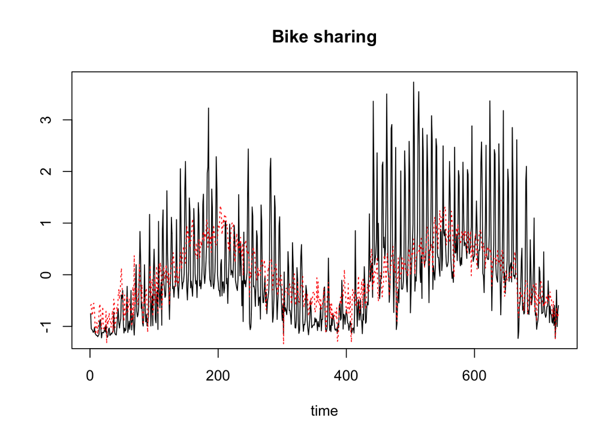

```r
plot(data_s$casual,type="l",xlab="time",ylab="",main="Bike sharing")
lines(model$fitted.values,lty=3,col="red")
```

## 2) Yacht hydrodynamic resistance

**Source.** UCI Machine Learning Repository, https://archive.ics.uci.edu/dataset/243/yacht+hydrodynamics. Original record: Gerritsma, Onnink and Versluis, *Geometry, resistance and stability of the Delft Systematic Yacht Hull Series*, 1981.

**Data.** The dataset describes 22 different hull forms (sailing yacht), each tested at multiple Froude numbers in a towing tank, producing 308 hull-form $\times$ Froude-number rows.

Variables:

`LCB` : longitudinal position of the center of buoyancy (% length).

`prismatic` : prismatic coefficient (dimensionless).

`L_disp` : length-displacement ratio.

`beam_draught` : beam-draught ratio.

`L_beam` : length-beam ratio.

`Froude` : Froude number (dimensionless, $Fn = v/\sqrt{gL}$), in [0.125, 0.45]. The dominant predictor.

`resistance` : residuary resistance per unit weight of displacement (target variable).

**Task.** The physics of the problem says that for sailing yachts the residuary resistance follows a power law of the Froude number with exponent close to 4 in the bulk regime. A good Bayesian project explores this:

1. **Log-log regression.** Fit
   $$\log(\mathrm{resistance}) = \beta_0 + \beta_F\,\log(\mathrm{Froude}) +
   \sum_k \beta_k\,\mathrm{hull}_k + \varepsilon\,.$$
   Verify that $\hat\beta_F \approx 4$.
2. **BAS / BMA.** Use `bas.lm` to enumerate the $2^5$ submodels over the five hull-geometry covariates and identify which of them (LCB, prismatic, L/disp, B/draught, L/beam) carry signal once `Froude` is in the model.
3. **Correct for heteroscedasticity.** Train the nonlinear model
   $$\mathrm{resistance} = k\,\mathrm{Froude}^{\gamma_F}\,\exp\left\{\sum_k
   \beta_k\,\mathrm{hull}_k \right\} + \varepsilon$$
   where only the form factors that appear relevant in the model selection phase are kept for the nonlinear modelling. Compare the results with the log-log regression and discuss the impact of the heteroscedasticity correction on the inference on $\gamma_F$ and on the hull-geometry covariates.
4. Plot the posterior predictive curves and compare the curves with or without the treatment of the heteroscedasticity and compare the curves with the data.

```r
rm(list=ls())
# Yacht hydrodynamics — UCI #243
yh = read.csv("data/yacht_hydro.csv")
dim(yh)
```

```
## [1] 308   7
```

```r
head(yh)
```

|  | LCB | prismatic | L_disp | beam_draught | L_beam | Froude | resistance |
| --- | --- | --- | --- | --- | --- | --- | --- |
| 1 | -2.3 | 0.568 | 4.78 | 3.99 | 3.17 | 0.125 | 0.11 |
| 2 | -2.3 | 0.568 | 4.78 | 3.99 | 3.17 | 0.150 | 0.27 |
| 3 | -2.3 | 0.568 | 4.78 | 3.99 | 3.17 | 0.175 | 0.47 |
| 4 | -2.3 | 0.568 | 4.78 | 3.99 | 3.17 | 0.200 | 0.78 |
| 5 | -2.3 | 0.568 | 4.78 | 3.99 | 3.17 | 0.225 | 1.18 |
| 6 | -2.3 | 0.568 | 4.78 | 3.99 | 3.17 | 0.250 | 1.82 |

```r
summary(yh)
```

```
##       LCB           prismatic          L_disp       beam_draught
##  Min.   :-5.000   Min.   :0.5300   Min.   :4.340   Min.   :2.810
##  1st Qu.:-2.400   1st Qu.:0.5460   1st Qu.:4.770   1st Qu.:3.750
##  Median :-2.300   Median :0.5650   Median :4.780   Median :3.955
##  Mean   :-2.382   Mean   :0.5641   Mean   :4.789   Mean   :3.937
##  3rd Qu.:-2.300   3rd Qu.:0.5740   3rd Qu.:5.100   3rd Qu.:4.170
##  Max.   : 0.000   Max.   :0.6000   Max.   :5.140   Max.   :5.350
##      L_beam          Froude         resistance
##  Min.   :2.730   Min.   :0.1250   Min.   : 0.0100
##  1st Qu.:3.150   1st Qu.:0.2000   1st Qu.: 0.7775
##  Median :3.150   Median :0.2875   Median : 3.0650
##  Mean   :3.207   Mean   :0.2875   Mean   :10.4954
##  3rd Qu.:3.510   3rd Qu.:0.3750   3rd Qu.:12.8150
##  Max.   :3.640   Max.   :0.4500   Max.   :62.4200
```

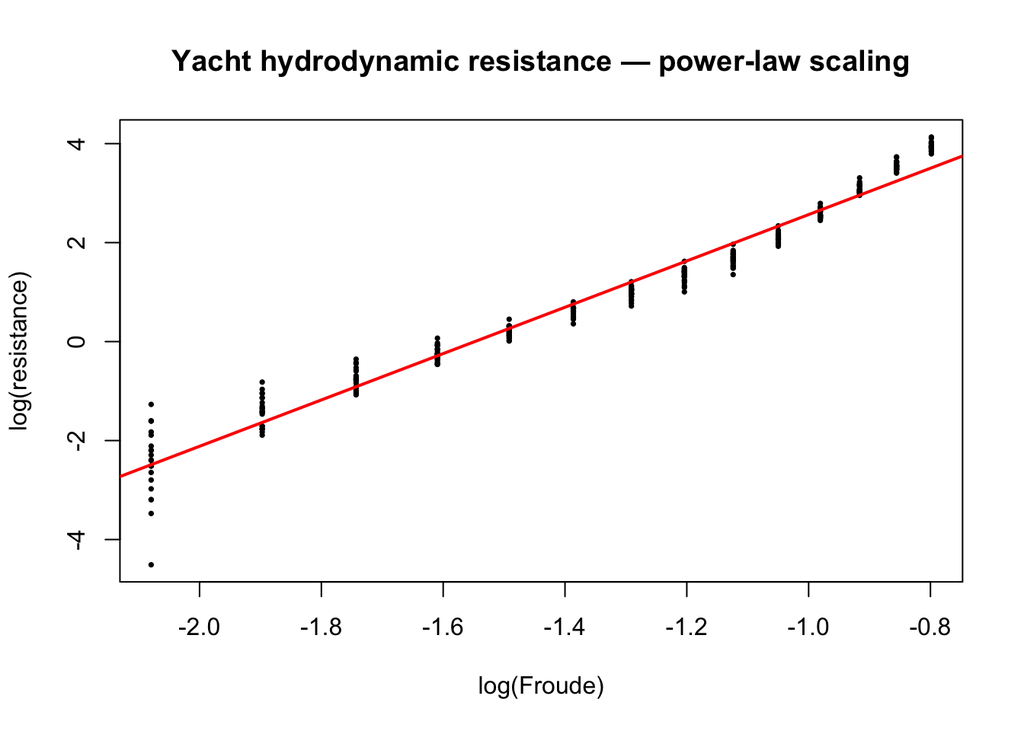

```r
# The power-law in Fn is best seen on log-log axes (drop F=0 rows if any)
plot(log(yh$Froude), log(yh$resistance + 1e-3),
     pch = 16, cex = 0.5,
     xlab = "log(Froude)", ylab = "log(resistance)",
     main = "Yacht hydrodynamic resistance — power-law scaling")
abline(lm(log(resistance + 1e-3) ~ log(Froude), data = yh),
       col = "red", lwd = 2)
```

## 3) Airline Customer satisfaction

**Source.** https://www.kaggle.com/datasets/raminhuseyn/airline-customer-satisfaction

**Data.** The dataset provides information on customer satisfaction levels for an undisclosed airline company. Although the name of the airline is not provided, the dataset contains a rich set of variables, with a total of 22 columns.

For convenience, we extracted a subset containing 1000 customers from the original dataset.

The dataset provides insights into customer satisfaction levels within an undisclosed airline company. While the specific airline name is withheld, the dataset is rich in information, containing 22 columns.

Column name Description:

Satisfaction. Indicates the satisfaction level of the customer.

Customer Type. Type of customer: ‘Loyal Customer’ or ‘Disloyal Customer’.

Age: Age of the customer.

Type of Travel. Purpose of the travel: ‘Business travel’ or ‘Personal Travel’.

Class: Class of travel. ‘Business’, ‘Eco’, or ‘Eco Plus’.

Flight Distance. The distance of the flight in kilometres

Seat comfort. Rating of seat comfort provided during the flight (1 to 5).

Departure/Arrival time convenient. Rating of the convenience of departure/arrival time (1 to 5).

Food and drink. Rating of food and drink quality provided during the flight (1 to 5).

Gate location. Rating of gate location convenience (1 to 5).

Inflight wifi service. Rating of inflight wifi service satisfaction (1 to 5).

Inflight entertainment. Rating of inflight entertainment satisfaction (1 to 5).

Online support. Rating of online customer support satisfaction (1 to 5).

Ease of Online booking. Rating of ease of online booking satisfaction (1 to 5).

On-board service. Rating of on-board service satisfaction (1 to 5).

Leg room service. Rating of leg room service satisfaction (1 to 5).

Baggage handling. Rating of baggage handling satisfaction (1 to 5).

Checkin service. Rating of check-in service satisfaction (1 to 5).

Cleanliness. Rating of cleanliness satisfaction (1 to 5). Online boarding Rating of online boarding satisfaction (1 to 5).

Departure Delay in Minutes. Total departure delay in minutes.

Arrival Delay in Minutes. Total arrival delay in minutes.

We select from the original dataset 1000 customers.

**Task.** Perform a suitable regression analysis for the categorical response variable . Identify the variables that are most strongly associated with customer satisfaction. A prediction exercise is required. Variable selection methods may also be discussed if desired.

It is recommended to start using only a subset of the covariates, for example:
$$\texttt{Age},\ \texttt{SeatComfort},\ \texttt{FlightDistance},\
\texttt{Class},\ \texttt{DepartureDelay},\ \texttt{ArrivalDelay}.$$

More data and info are provided at https://www.kaggle.com/datasets/raminhuseyn/airline-customer-satisfaction

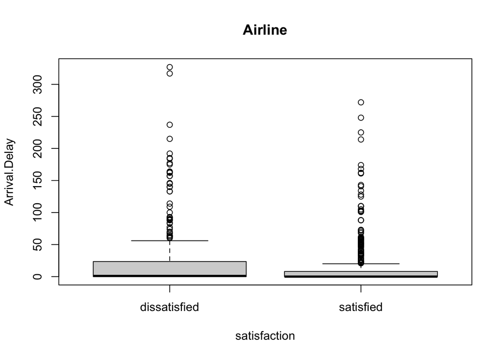

```r
rm(list=ls())
# Airline Customer satisfaction
# https://www.kaggle.com/datasets/raminhuseyn/airline-customer-satisfaction
data = read.csv("data/Airline_customer_satisfaction.csv")
#index = sample(1:nrow(data),1000,replace=F)
#airline_sub = data[index,]
#row.names(airline_sub) = 1:nrow(airline_sub)
#write.csv(airline_sub,"data/airline_sub.csv")
#head(airline_sub)

airline_sub = read.csv("data/airline_sub.csv")

boxplot(airline_sub$Arrival.Delay.in.Minutes~airline_sub$satisfaction,xlab="satisfaction",ylab="Arrival.Delay",main="Airline")
```

## 4) Bank Marketing

**Source.** https://archive.ics.uci.edu/dataset/222/bank+marketing

**Data.** The dataset is related to direct marketing campaigns conducted by a Portuguese banking institution. The marketing campaigns were based on phone calls. Often, more than one contact with the same client was required in order to determine whether the client would subscribe to a bank term deposit (yes) or not (no).

**Task.** Perform a suitable regression analysis for the categorical response variable corresponding to the subscription of a bank term deposit. Identify the variables that are most strongly associated with the response. A prediction exercise is required. Variable selection methods may also be discussed if desired.

Since the dataset contains many categorical covariates, you may choose to work only with a subset of them.

```r
rm(list=ls())
data = data.frame(read.csv("data/bank.csv", header=FALSE, sep=";"))
names=data[1,]
data=data[-1,]
colnames(data)<-names
head(data)
```

|  | age | job | marital | education | default | balance | housing | loan | contact | day | month | duration | campaign | pdays | previous | poutcome | y |
| --- | --- | --- | --- | --- | --- | --- | --- | --- | --- | --- | --- | --- | --- | --- | --- | --- | --- |
| 2 | 30 | unemployed | married | primary | no | 1787 | no | no | cellular | 19 | oct | 79 | 1 | -1 | 0 | unknown | no |
| 3 | 33 | services | married | secondary | no | 4789 | yes | yes | cellular | 11 | may | 220 | 1 | 339 | 4 | failure | no |
| 4 | 35 | management | single | tertiary | no | 1350 | yes | no | cellular | 16 | apr | 185 | 1 | 330 | 1 | failure | no |
| 5 | 30 | management | married | tertiary | no | 1476 | yes | yes | unknown | 3 | jun | 199 | 4 | -1 | 0 | unknown | no |
| 6 | 59 | blue-collar | married | secondary | no | 0 | yes | no | unknown | 5 | may | 226 | 1 | -1 | 0 | unknown | no |
| 7 | 35 | management | single | tertiary | no | 747 | no | no | cellular | 23 | feb | 141 | 2 | 176 | 3 | failure | no |

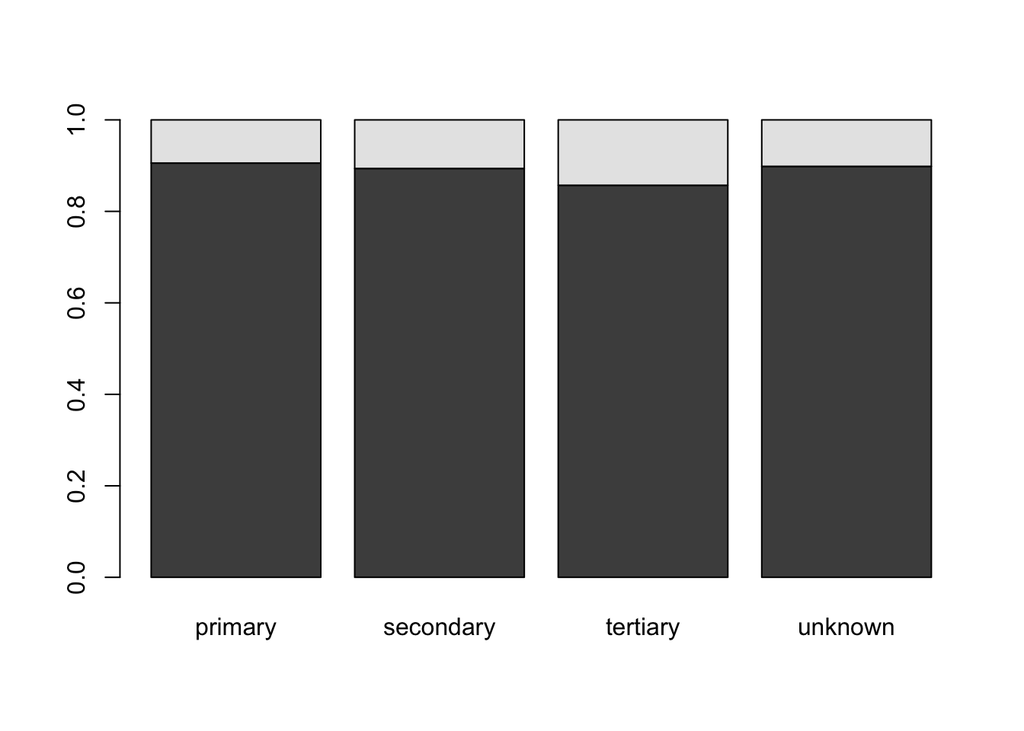

```r
data$y <- ifelse(data$y == "yes", 1, 0)
tab <- table(data$education, data$y)
prop <- prop.table(tab, margin = 1)
barplot(t(prop))
```

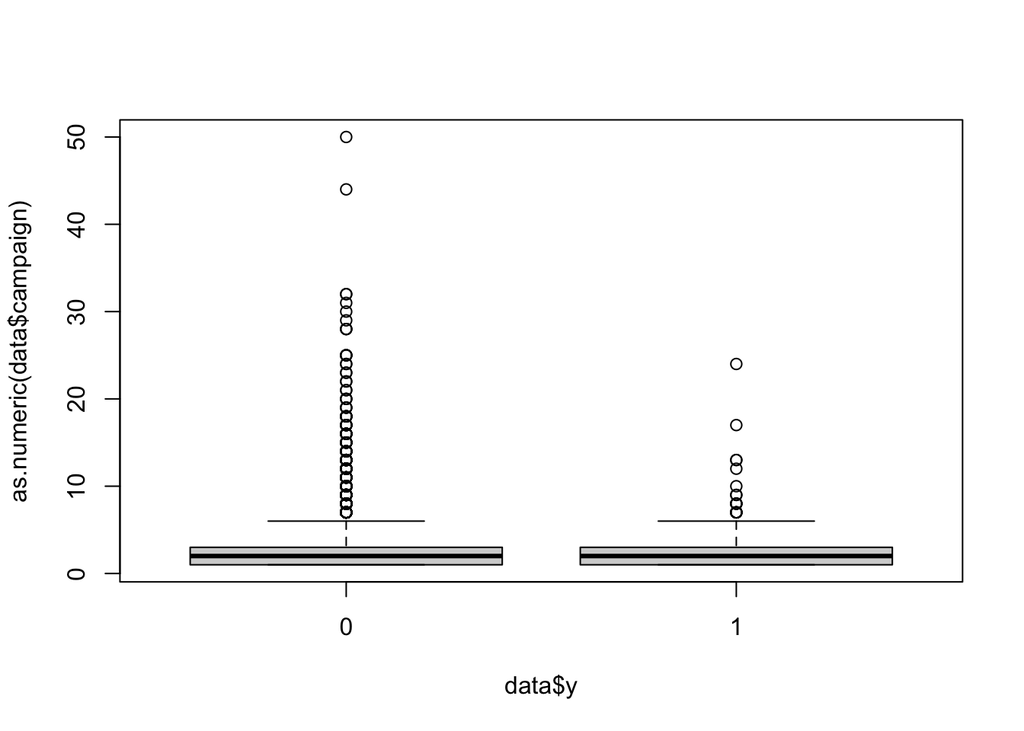

```r
boxplot(as.numeric(data$campaign)~data$y)
```